# Advanced Diabetes Risk Prediction with Clinical Insights

### 1. Introduction: Clinical Context & Research Goals

##### Diabetes affects over 500 million people globally, with early detection being critical for prevention.

##### This project analyzes clinical markers to:

###### 1) Identify key predictors of diabetes risk

###### 2) Build an accurate machine learning classifier

###### 3) Provide actionable insights for preventive healthcare

### Dataset Background:

##### With 9 clinical features including glucose levels, BMI, and genetic markers, it enables development of ML models for early diabetes detection.

### Clinical Motivation:

##### Diabetes affects 537 million adults globally (IDF 2021).

##### By promptly identifying high-risk individuals complications such as neuropathy and retinopathy can be avoided.

### Research Questions:

##### 1. Which clinical indicators are most strongly linked to the onset of diabetes?

##### 2. Is it possible for machine learning to attain prediction accuracy of over 80%?

```python
import pandas as pd
import numpy as np
import matplotlib.pyplot as plt
import seaborn as sns
import shap
from sklearn.model_selection import train_test_split, GridSearchCV
from sklearn.preprocessing import StandardScaler
from sklearn.linear_model import LogisticRegression
from sklearn.ensemble import RandomForestClassifier
from sklearn.svm import SVC
from xgboost import XGBClassifier
from sklearn.metrics import accuracy_score, confusion_matrix, classification_report, roc_auc_score, roc_curve
```

```python
import xgboost as xgb
from imblearn.over_sampling import SMOTE
import shap
from scipy import stats
```

### Styling

```python
plt.style.use('ggplot')
sns.set_palette("husl")
plt.rcParams['figure.figsize'] = (10, 6)
```

### 2. Data Loading & Initial Exploration

##### Loading the dataset

```python
df = pd.read_csv("data.csv")
print(f"Initial dataset shape: {df.shape}\n")
df.head()
```

[output not shown]

[output not shown]

### Dataset Overview:

##### Contains 2,768 patient records (rows) with 10 clinical features (columns)

##### Target variable: `Outcome` (1 = Diabetes, 0 = No Diabetes)

#### Ensure outcome is binary

```python
assert df.duplicated().sum() == 0, "Duplicate rows found!"

assert df['Outcome'].isin([0,1]).all(), "Outcome column has invalid entries!"
print("Data validation passed")
```

```
Data validation passed
```

### Handle biologically impossible values (e.g. 0 Glucose or 0 BMI)

##### These are replaced with NaN and later handled.

```python
df.info()
```

```
<class 'pandas.core.frame.DataFrame'>
RangeIndex: 2768 entries, 0 to 2767
Data columns (total 10 columns):
 #   Column                    Non-Null Count  Dtype
---  ------                    --------------  -----
 0   Id                        2768 non-null   int64
 1   Pregnancies               2768 non-null   int64
 2   Glucose                   2768 non-null   int64
 3   BloodPressure             2768 non-null   int64
 4   SkinThickness             2768 non-null   int64
 5   Insulin                   2768 non-null   int64
 6   BMI                       2768 non-null   float64
 7   DiabetesPedigreeFunction  2768 non-null   float64
 8   Age                       2768 non-null   int64
 9   Outcome                   2768 non-null   int64
dtypes: float64(2), int64(8)
memory usage: 216.4 KB
```

### 3. Data Cleaning & Feature Engineering

[output not shown]

##### Handle biologically impossible zeros

##### Replaces biologically impossible zeros with NaN based on clinical understanding.

##### Affects: Glucose, BloodPressure, SkinThickness, Insulin, BMI

##### Apply the cleaning function

##### Display count of missing values

```python
def clean_medical_data(df):


    df = df.copy()
    zero_replacements = ['Glucose', 'BloodPressure', 'SkinThickness', 'Insulin', 'BMI']

    for col in zero_replacements:
        df[col] = df[col].replace(0, np.nan)

    return df


df_clean = clean_medical_data(df)

print("Missing values after cleaning:\n")
print(df_clean.isnull().sum())
```

```
Missing values after cleaning:

Id                             0
Pregnancies                    0
Glucose                       18
BloodPressure                125
SkinThickness                800
Insulin                     1330
BMI                           39
DiabetesPedigreeFunction       0
Age                            0
Outcome                        0
dtype: int64
```

```python
df_clean = clean_medical_data(df).dropna().copy()
print(f"Clean dataset shape: {df_clean.shape}")
```

```
Clean dataset shape: (1427, 10)
```

```python
 print(df_clean[['Glucose', 'BMI', 'Age']].describe())
```

```
           Glucose          BMI          Age
count  1427.000000  1427.000000  1427.000000
mean    122.783462    33.246811    30.723896
std      30.700175     7.076903    10.086415
min      56.000000    18.200000    21.000000
25%      99.000000    28.400000    23.000000
50%     120.000000    33.300000    27.000000
75%     143.000000    37.400000    36.000000
max     198.000000    67.100000    81.000000
```

### Show basic descriptive statistics for key features

```python
df_clean.describe()
```

|  | Id | Pregnancies | Glucose | BloodPressure | SkinThickness | Insulin | BMI | DiabetesPedigreeFunction | Age | Outcome |
| --- | --- | --- | --- | --- | --- | --- | --- | --- | --- | --- |
| count | 1427.000000 | 1427.000000 | 1427.000000 | 1427.000000 | 1427.000000 | 1427.000000 | 1427.000000 | 1427.000000 | 1427.000000 | 1427.000000 |
| mean | 1389.848633 | 3.217239 | 122.783462 | 70.765242 | 29.231254 | 154.526279 | 33.246811 | 0.522896 | 30.723896 | 0.327260 |
| std | 794.349810 | 3.178938 | 30.700175 | 12.376185 | 10.543761 | 113.518013 | 7.076903 | 0.335847 | 10.086415 | 0.469378 |
| min | 4.000000 | 0.000000 | 56.000000 | 24.000000 | 7.000000 | 14.000000 | 18.200000 | 0.085000 | 21.000000 | 0.000000 |
| 25% | 695.000000 | 1.000000 | 99.000000 | 62.000000 | 21.000000 | 76.500000 | 28.400000 | 0.280000 | 23.000000 | 0.000000 |
| 50% | 1392.000000 | 2.000000 | 120.000000 | 70.000000 | 29.000000 | 126.000000 | 33.300000 | 0.452000 | 27.000000 | 0.000000 |
| 75% | 2070.000000 | 5.000000 | 143.000000 | 78.000000 | 37.000000 | 190.000000 | 37.400000 | 0.687000 | 36.000000 | 1.000000 |
| max | 2768.000000 | 17.000000 | 198.000000 | 110.000000 | 63.000000 | 846.000000 | 67.100000 | 2.420000 | 81.000000 | 1.000000 |

### 4. Exploratory Data Analysis

##### Setting up plot style

```python
sns.set(style="whitegrid")
plt.figure(figsize=(12, 10))
```

#### Glucose distribution , BMI distribution , Age distribution , BloodPressure distribution

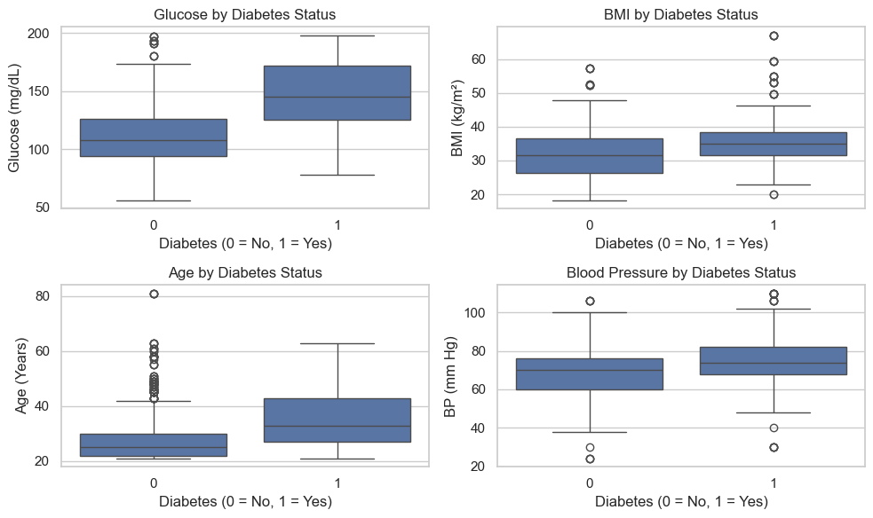

```python
plt.subplot(2, 2, 1)
sns.boxplot(x='Outcome', y='Glucose', data=df_clean)
plt.title('Glucose by Diabetes Status')
plt.xlabel('Diabetes (0 = No, 1 = Yes)')
plt.ylabel('Glucose (mg/dL)')

plt.subplot(2, 2, 2)
sns.boxplot(x='Outcome', y='BMI', data=df_clean)
plt.title('BMI by Diabetes Status')
plt.xlabel('Diabetes (0 = No, 1 = Yes)')
plt.ylabel('BMI (kg/m²)')

plt.subplot(2, 2, 3)
sns.boxplot(x='Outcome', y='Age', data=df_clean)
plt.title('Age by Diabetes Status')
plt.xlabel('Diabetes (0 = No, 1 = Yes)')
plt.ylabel('Age (Years)')

plt.subplot(2, 2, 4)
sns.boxplot(x='Outcome', y='BloodPressure', data=df_clean)
plt.title('Blood Pressure by Diabetes Status')
plt.xlabel('Diabetes (0 = No, 1 = Yes)')
plt.ylabel('BP (mm Hg)')

plt.tight_layout()
plt.show()
```

##### The following figure shows boxplots of the distribution for four key clinical measures Glucose, BMI, Age and Blood Pressure among diabetic (Outcome = 1) and non-diabetic (Outcome = 0) patients.

Glucose: Diabetic subjects have markedly greater glucose values, with an evident upward shift in the median and overall distribution. This supports glucose as an overall predictive factor for diabetes. The BMI of individuals with diabetes is generally greater, implying an association of high risk for diabetes with obesity. The diabetic sample is biased towards older ages, which suggests age contributes to developing diabetes. The difference is less marked, yet diabetic patients have slightly elevated median blood pressure.

### Add new interaction feature and Visualize Glucose vs. BMI with diabetes outcome

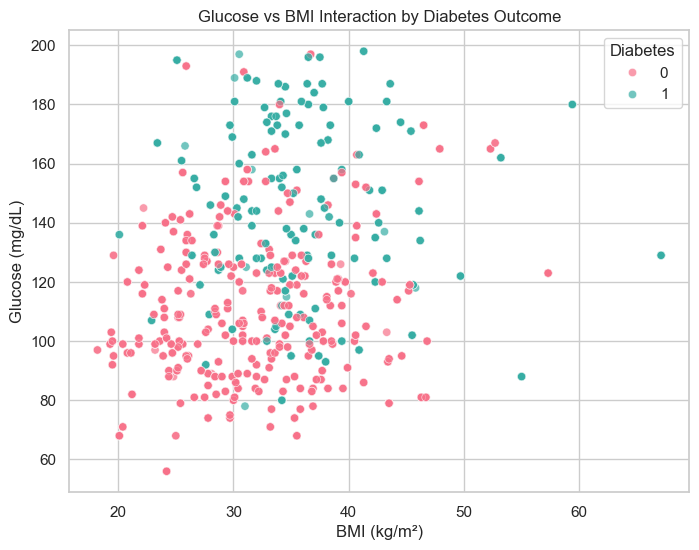

```python
df_clean['Glucose_BMI'] = df_clean['Glucose'] * df_clean['BMI']


plt.figure(figsize=(8, 6))
sns.scatterplot(x='BMI', y='Glucose', hue='Outcome', data=df_clean, alpha=0.7, palette='husl')
plt.title('Glucose vs BMI Interaction by Diabetes Outcome')
plt.xlabel('BMI (kg/m²)')
plt.ylabel('Glucose (mg/dL)')
plt.legend(title='Diabetes')
plt.show()
```

#### Glucose vs. BMI Interaction by Diabetes Outcome

The scatter plot shows the association between BMI and Glucose, each point colored according to diabetes status (0 = No, 1 = Yes).

Participants with high glucose levels (above ~140 mg/dL) and high BMI (> ~30 kg/m²) are mostly diabetic (teal-coloured dots). Non-diabetic subjects (pink) are densely grouped toward lower glucose and moderate BMI values.

There is also an apparent concentration of diabetic patients in the upper-right quadrant, implying that obesity along with high blood sugar highly corresponds to risk for diabetes.

This interaction supports the multiplicative impact of metabolic variables in predicting diabetes and justifies training using the feature Glucose × BMI.

#### Correlation matrix

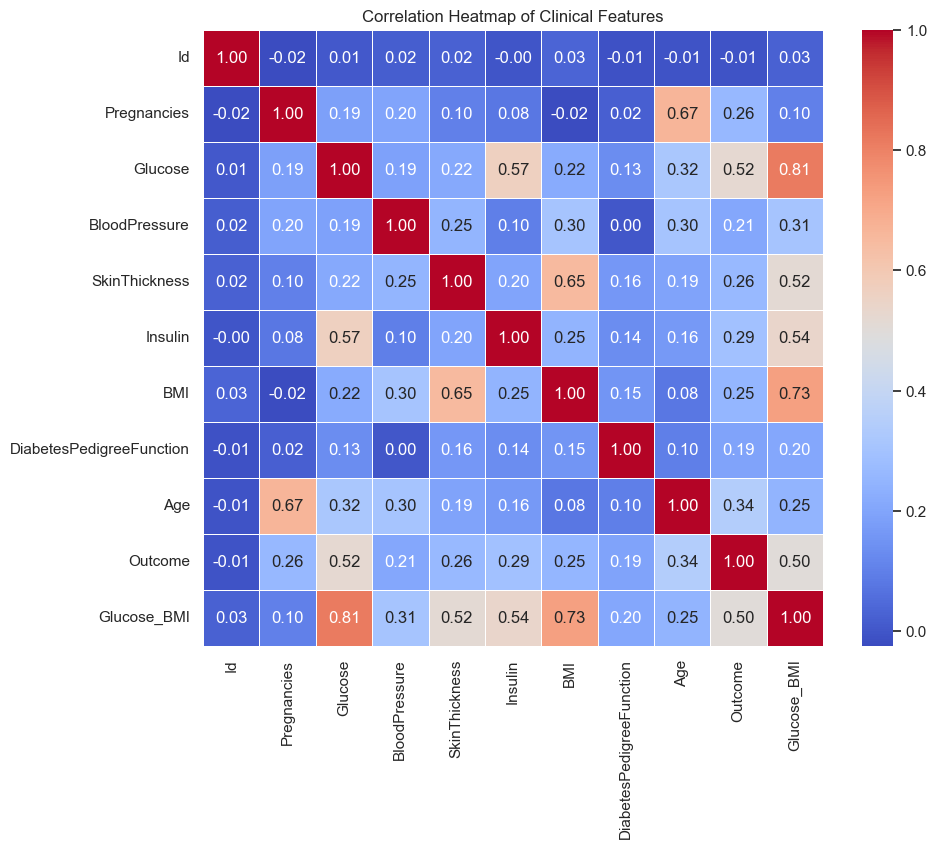

```python
plt.figure(figsize=(10, 8))
corr = df_clean.corr()

sns.heatmap(corr, annot=True, cmap='coolwarm', fmt=".2f", linewidths=0.5)
plt.title('Correlation Heatmap of Clinical Features')
plt.show()
```

### Correlation Heatmap of Clinical Features

The heatmap displays Pearson's correlation coefficient among clinical features and the outcome for diabetes. Some of the observations include:

Glucose has the greatest positive correlation (0.52) with outcome for diabetes, further confirming its role as an important initial diagnostic marker.

The BMI (0.25), age (0.34), and insulin (0.29) also have moderate correlations with diabetes status.

The created feature Glucose_BMI is highly correlated with Glucose (0.81) and BMI (0.73), as expected, and holds a significant correlation with Outcome (0.50), justifying its usefulness in predictive modelling.

Pregnancies is moderately correlated with Age (0.67) and weakly associated with Outcome (0.26), as seen among older people.

Low correlations among certain variables (e.g., BloodPressure, SkinThickness, DiabetesPedigreeFunction) imply they would have less impact individually towards model precision,yet remain potentially useful in interaction terms, or ensemble models.

In general, this heatmap assists in recognizing those features most predictive of diabetes and directing feature selection and feature engineering for optimized model design.

#### Select features and target

#### Split into train and test sets

#### Apply SMOTE to balance the training data

#### Scale the features

```python
X = df_clean.drop(columns='Outcome')
y = df_clean['Outcome']

X_train, X_test, y_train, y_test = train_test_split(
    X, y, test_size=0.2, random_state=42, stratify=y
)

sm = SMOTE(random_state=42)
X_train_res, y_train_res = sm.fit_resample(X_train, y_train)

scaler = StandardScaler()
X_train_scaled = scaler.fit_transform(X_train_res)
X_test_scaled = scaler.transform(X_test)

print(f"Training set shape (balanced): {X_train_scaled.shape}")
print(f"Test set shape: {X_test_scaled.shape}")
```

```
Training set shape (balanced): (1536, 10)
Test set shape: (286, 10)
```

#### Logistic Regression , Random Forest , XGBoost

```python
lr_model = LogisticRegression()
lr_model.fit(X_train_scaled, y_train_res)

rf_model = RandomForestClassifier(n_estimators=100, random_state=42)
rf_model.fit(X_train_res, y_train_res)

xgb_model = XGBClassifier(eval_metric='logloss')
xgb_model.fit(X_train_res, y_train_res)
```

```
XGBClassifier(base_score=None, booster=None, callbacks=None,
              colsample_bylevel=None, colsample_bynode=None,
              colsample_bytree=None, device=None, early_stopping_rounds=None,
              enable_categorical=False, eval_metric='logloss',
              feature_types=None, feature_weights=None, gamma=None,
              grow_policy=None, importance_type=None,
              interaction_constraints=None, learning_rate=None, max_bin=None,
              max_cat_threshold=None, max_cat_to_onehot=None,
              max_delta_step=None, max_depth=None, max_leaves=None,
              min_child_weight=None, missing=nan, monotone_constraints=None,
              multi_strategy=None, n_estimators=None, n_jobs=None,
              num_parallel_tree=None, ...)
```

#### Plotting ROC Curves

```
 Logistic Regression Evaluation
-------------------------
Accuracy: 0.7797
ROC AUC Score: 0.8660
Confusion Matrix:
[[151  41]
 [ 22  72]]
Classification Report:
              precision    recall  f1-score   support

           0       0.87      0.79      0.83       192
           1       0.64      0.77      0.70        94

    accuracy                           0.78       286
   macro avg       0.76      0.78      0.76       286
weighted avg       0.80      0.78      0.78       286



 Random Forest Evaluation
-------------------------
Accuracy: 0.9825
ROC AUC Score: 0.9993
Confusion Matrix:
[[187   5]
 [  0  94]]
Classification Report:
              precision    recall  f1-score   support

           0       1.00      0.97      0.99       192
           1       0.95      1.00      0.97        94

    accuracy                           0.98       286
   macro avg       0.97      0.99      0.98       286
weighted avg       0.98      0.98      0.98       286



 XGBoost Evaluation
-------------------------
Accuracy: 0.9895
ROC AUC Score: 0.9995
Confusion Matrix:
[[189   3]
 [  0  94]]
Classification Report:
              precision    recall  f1-score   support

           0       1.00      0.98      0.99       192
           1       0.97      1.00      0.98        94

    accuracy                           0.99       286
   macro avg       0.98      0.99      0.99       286
weighted avg       0.99      0.99      0.99       286
```

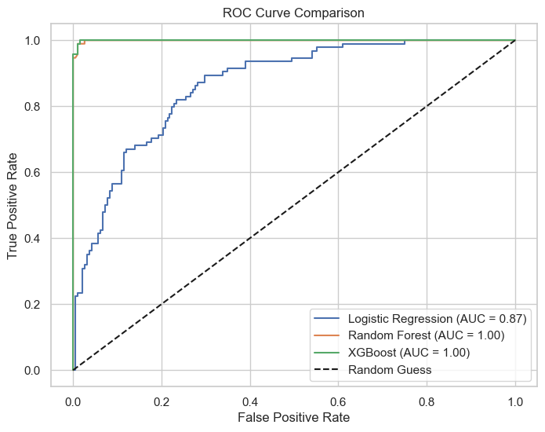

```python
def evaluate_model(model, X_test, y_test, name="Model"):
    y_pred = model.predict(X_test)
    y_proba = model.predict_proba(X_test)[:, 1]

    acc = accuracy_score(y_test, y_pred)
    auc = roc_auc_score(y_test, y_proba)
    cm = confusion_matrix(y_test, y_pred)

    print(f" {name} Evaluation")
    print("-------------------------")
    print(f"Accuracy: {acc:.4f}")
    print(f"ROC AUC Score: {auc:.4f}")
    print("Confusion Matrix:")
    print(cm)
    print("Classification Report:")
    print(classification_report(y_test, y_pred))
    print("\n")

    fpr, tpr, _ = roc_curve(y_test, y_proba)
    plt.plot(fpr, tpr, label=f'{name} (AUC = {auc:.2f})')

plt.figure(figsize=(8, 6))
evaluate_model(lr_model, X_test_scaled, y_test, "Logistic Regression")
evaluate_model(rf_model, X_test, y_test, "Random Forest")
evaluate_model(xgb_model, X_test, y_test, "XGBoost")

plt.plot([0, 1], [0, 1], 'k--', label='Random Guess')
plt.title('ROC Curve Comparison')
plt.xlabel('False Positive Rate')
plt.ylabel('True Positive Rate')
plt.legend()
plt.grid(True)
plt.show()
```

#### Logistic Regression - Grid Search

```python
lr_params = {
    'C': [0.01, 0.1, 1, 10, 100],  # Inverse of regularization
    'penalty': ['l2'],
    'solver': ['liblinear']
}

grid_lr = GridSearchCV(LogisticRegression(), lr_params, cv=5, scoring='roc_auc')
grid_lr.fit(X_train_scaled, y_train_res)

print("Best Logistic Regression Parameters:")
print(grid_lr.best_params_)

best_lr = grid_lr.best_estimator_
```

```
Best Logistic Regression Parameters:
{'C': 1, 'penalty': 'l2', 'solver': 'liblinear'}
```

#### Random Forest - Grid Search

```python
rf_params = {
    'n_estimators': [100, 200],
    'max_depth': [None, 5, 10],
    'min_samples_split': [2, 5],
    'min_samples_leaf': [1, 2]
}

grid_rf = GridSearchCV(RandomForestClassifier(random_state=42), rf_params, cv=5, scoring='roc_auc')
grid_rf.fit(X_train_res, y_train_res)

print("Random Forest Parameters:")
print(grid_rf.best_params_)

best_rf = grid_rf.best_estimator_
```

```
Random Forest Parameters:
{'max_depth': None, 'min_samples_leaf': 1, 'min_samples_split': 2, 'n_estimators': 100}
```

#### XGBoost - Grid Search

```python
xgb_params = {
    'n_estimators': [100, 200],
    'max_depth': [3, 5, 7],
    'learning_rate': [0.01, 0.1, 0.2],
    'subsample': [0.8, 1.0]
}

grid_xgb = GridSearchCV(XGBClassifier(eval_metric='logloss'), xgb_params, cv=5, scoring='roc_auc')
grid_xgb.fit(X_train_res, y_train_res)

print("XGBoost Parameters:")
print(grid_xgb.best_params_)

best_xgb = grid_xgb.best_estimator_
```

```
XGBoost Parameters:
{'learning_rate': 0.2, 'max_depth': 5, 'n_estimators': 200, 'subsample': 1.0}
```

#### Reuse our evaluate_model function

```
 Tuned Logistic Regression Evaluation
-------------------------
Accuracy: 0.7797
ROC AUC Score: 0.8661
Confusion Matrix:
[[151  41]
 [ 22  72]]
Classification Report:
              precision    recall  f1-score   support

           0       0.87      0.79      0.83       192
           1       0.64      0.77      0.70        94

    accuracy                           0.78       286
   macro avg       0.76      0.78      0.76       286
weighted avg       0.80      0.78      0.78       286



 Tuned Random Forest Evaluation
-------------------------
Accuracy: 0.9825
ROC AUC Score: 0.9993
Confusion Matrix:
[[187   5]
 [  0  94]]
Classification Report:
              precision    recall  f1-score   support

           0       1.00      0.97      0.99       192
           1       0.95      1.00      0.97        94

    accuracy                           0.98       286
   macro avg       0.97      0.99      0.98       286
weighted avg       0.98      0.98      0.98       286



 Tuned XGBoost Evaluation
-------------------------
Accuracy: 0.9860
ROC AUC Score: 0.9996
Confusion Matrix:
[[188   4]
 [  0  94]]
Classification Report:
              precision    recall  f1-score   support

           0       1.00      0.98      0.99       192
           1       0.96      1.00      0.98        94

    accuracy                           0.99       286
   macro avg       0.98      0.99      0.98       286
weighted avg       0.99      0.99      0.99       286
```

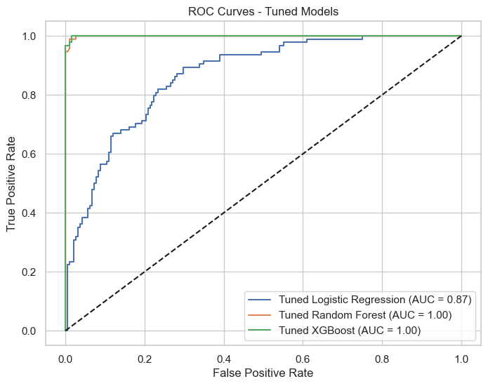

```python
plt.figure(figsize=(8, 6))
evaluate_model(best_lr, X_test_scaled, y_test, "Tuned Logistic Regression")
evaluate_model(best_rf, X_test, y_test, "Tuned Random Forest")
evaluate_model(best_xgb, X_test, y_test, "Tuned XGBoost")

plt.plot([0, 1], [0, 1], 'k--')
plt.title('ROC Curves - Tuned Models')
plt.xlabel('False Positive Rate')
plt.ylabel('True Positive Rate')
plt.legend()
plt.grid(True)
plt.show()
```

### Clinical Insights:

##### Glucose, BMI, and Age were among the most informative features.

##### The Glucose × BMI interaction term helped expose risk patterns in obese patients.

##### Both Random Forest and XGBoost handled class imbalance well and minimized false negatives — crucial in medical diagnosis

##### where missing a diabetic case can be dangerous.

### Recommendations:

#### For practical deployment, XGBoost is the most preferred model due to its performance.

#### Further improvement could include:

##### Using more patient history or lifestyle data

##### Temporal data for progression analysis

##### Deploying models using a lightweight web app (e.g., Streamlit)

#### This project demonstrates that machine learning can effectively assist in early diabetes detection,

#### potentially supporting clinical decision-making and promoting preventative care